# GDAL Warp

(https://www.gdal.org/gdalwarp.html)

**Author**: Jacob Arndt  
**Date**: 3/3/2019

## Contents

1. Preliminaries
2. Reprojecting Rasters
3. Rescaling and Resampling
4. Clipping

# Preliminaries

## Import modules

- **timeit** is used to do some basic time tests
- **gdal** is used for reading, writing, and manipulating geospatial data
- **numpy** is used to work with the image data in the form of numpy arrays
- **matplotlib** is used for visualization and sanity checks

```python
import timeit

from osgeo import gdal
import numpy as np
import matplotlib.pyplot as plt
```

## Notes about the input data (imagery)

```python
image_filename = "D:/Imagery/naip/m_3712221_se_10_h_20160625.tif"

ds = gdal.Open(image_filename) # open the file

# print out some basic information about the number of pixels in the image
print("number of rows: \n",
      ds.RasterYSize, "\n")
print("number of columns: \n",
      ds.RasterXSize, "\n")
print("number of bands (or channels): \n",
      ds.RasterCount, "\n")
print("geotransform: \n (origin x, pixel resolution x, pixel rotation x, origin y, pixel rotation y, pixel resolution y): \n",
      ds.GetGeoTransform(), "\n")
print("projection: \n",
     ds.GetProjectionRef()) # not sure what the difference is between ds.GetProjection() and ds.GetProjectionRef()

ds = None # close the dataset
```

```
number of rows:
 12130

number of columns:
 9770

number of bands (or channels):
 4

geotransform:
 (origin x, pixel resolution x, pixel rotation x, origin y, pixel rotation y, pixel resolution y):
 (549444.0, 0.6, 0.0, 4171482.0, 0.0, -0.6)

projection:
 PROJCS["NAD83 / UTM zone 10N",GEOGCS["NAD83",DATUM["North_American_Datum_1983",SPHEROID["GRS 1980",6378137,298.257222101,AUTHORITY["EPSG","7019"]],TOWGS84[0,0,0,0,0,0,0],AUTHORITY["EPSG","6269"]],PRIMEM["Greenwich",0,AUTHORITY["EPSG","8901"]],UNIT["degree",0.0174532925199433,AUTHORITY["EPSG","9122"…
```

## Part 1: Reprojecting - Changing the image's geographic coordinate system to WGS84

The image we are working with is in a projected coordinate system. To be be specific, it is projected in UTM zone 10N using the geographic coordinate system North American Datum 1983 (NAD83). To reproject rasters we will use GDAL warp. GDAL warp is a handy utility that can do more than just reproject rasters. It can be used to mosaic images together, resample pixels, clip images to polygons, and much more.

The easiest way to specify projections in GDAL is to use EPSG codes.

#### 1.1. Reproject data in-memory (i.e. not writing a new file to disk)

```python
ds = gdal.Open(image_filename)
src_srs = ds.GetProjectionRef() # the original spatial reference system

target_srs='EPSG:32610'

# create a warp options object
warp_opts = gdal.WarpOptions(srcSRS=src_srs,
                             dstSRS=target_srs,
                             format="MEM")

# call gdal.Warp() with the appropriate parameters
out_ds = gdal.Warp(srcDSOrSrcDSTab=ds,
                   destNameOrDestDS="",
                   options=warp_opts)

print("input spatial reference: \n----------------------\n", src_srs, "\n")
print("output spatial reference: \n---------------------\n", out_ds.GetProjectionRef())
```

```
input spatial reference:
----------------------
 PROJCS["NAD83 / UTM zone 10N",GEOGCS["NAD83",DATUM["North_American_Datum_1983",SPHEROID["GRS 1980",6378137,298.257222101,AUTHORITY["EPSG","7019"]],TOWGS84[0,0,0,0,0,0,0],AUTHORITY["EPSG","6269"]],PRIMEM["Greenwich",0,AUTHORITY["EPSG","8901"]],UNIT["degree",0.0174532925199433,AUTHORITY["EPSG","9122"…

output spatial reference:
---------------------
 PROJCS["WGS 84 / UTM zone 10N",GEOGCS["WGS 84",DATUM["WGS_1984",SPHEROID["WGS 84",6378137,298.257223563,AUTHORITY["EPSG","7030"]],AUTHORITY["EPSG","6326"]],PRIMEM["Greenwich",0,AUTHORITY["EPSG","8901"]],UNIT["degree",0.0174532925199433,AUTHORITY["EPSG","9122"]],AUTHORITY["EPSG","4326"]],PROJECTION[…
```

#### 1.2. Reproject data and writing a new file

```python
ds = gdal.Open(image_filename)

src_srs = ds.GetProjectionRef() # the original spatial reference system
target_srs='EPSG:32610'

# create a warp options object
warp_opts = gdal.WarpOptions(srcSRS=src_srs,
                             dstSRS=target_srs,
                             format="GTiff")

# call gdal.Warp() with the appropriate parameters
out_ds = gdal.Warp(srcDSOrSrcDSTab=ds,
                   destNameOrDestDS="D:/Imagery/naip/out_image_wgs84utm10n.tif",
                   options=warp_opts)
print(out_ds.GetProjectionRef())

out_ds = None # dereference the object (close the file) to write
ds = None # close the original file
```

```
PROJCS["WGS 84 / UTM zone 10N",GEOGCS["WGS 84",DATUM["WGS_1984",SPHEROID["WGS 84",6378137,298.257223563,AUTHORITY["EPSG","7030"]],AUTHORITY["EPSG","6326"]],PRIMEM["Greenwich",0,AUTHORITY["EPSG","8901"]],UNIT["degree",0.0174532925199433,AUTHORITY["EPSG","9122"]],AUTHORITY["EPSG","4326"]],PROJECTION["…
```

#### 1.3 Reprojecting data in parallel

`gdal.WarpOptions()` has a "multithread" keyword argument that we can use to run `gdal.Warp()` in parallel. To take advantage of this, all we have to do is set the "multithread" argument to `True`. The examples below show how to reproject in parallel and compares the time it takes to do this in parallel as opposed to doing it sequentially.

```python
ds = gdal.Open(image_filename)
src_srs = ds.GetProjectionRef() # the original spatial reference system

target_srs='EPSG:32610'

def reproject_parallel():
    # create a warp options object
    warp_opts = gdal.WarpOptions(srcSRS=src_srs,
                                 dstSRS=target_srs,
                                 format="MEM",
                                 multithread=True)

    # call gdal.Warp() with the appropriate parameters
    out_ds = gdal.Warp(srcDSOrSrcDSTab=ds,
                       destNameOrDestDS="",
                       options=warp_opts)

def reproject_sequential():
    # create a warp options object
    warp_opts = gdal.WarpOptions(srcSRS=src_srs,
                                 dstSRS=target_srs,
                                 format="MEM",
                                 multithread=False)

    # call gdal.Warp() with the appropriate parameters
    out_ds = gdal.Warp(srcDSOrSrcDSTab=ds,
                       destNameOrDestDS="",
                       options=warp_opts)

# run time trials for each method
parallel_times = timeit.repeat("reproject_parallel()", setup="from __main__ import reproject_parallel", number=1, repeat=5)
sequential_times = timeit.repeat("reproject_sequential()", setup="from __main__ import reproject_sequential", number=1, repeat=5)
print("mean parallel time: ", np.mean(parallel_times))
print("mean sequential time: ", np.mean(sequential_times))
```

```
mean parallel time:  2.1323445706618713
mean sequential time:  2.6955399894567336
```

## Part 2: Changing Spatial Resolution and Resampling

```python
ds = gdal.Open(image_filename)

target_x_res = 1.2
target_y_res = -1.2
resample_alg = "near"

"""
possible resampling algorithms:
---------------------------------
near: nearest neighbour resampling (default, fastest algorithm, worst interpolation quality).
bilinear: bilinear resampling.
cubic: cubic resampling.
cubicspline: cubic spline resampling.
lanczos: Lanczos windowed sinc resampling.
average: average resampling, computes the average of all non-NODATA contributing pixels. (GDAL >= 1.10.0)
mode: mode resampling, selects the value which appears most often of all the sampled points. (GDAL >= 1.10.0)
max: maximum resampling, selects the maximum value from all non-NODATA contributing pixels. (GDAL >= 2.0.0)
min: minimum resampling, selects the minimum value from all non-NODATA contributing pixels. (GDAL >= 2.0.0)
med: median resampling, selects the median value of all non-NODATA contributing pixels. (GDAL >= 2.0.0)
q1: first quartile resampling, selects the first quartile value of all non-NODATA contributing pixels. (GDAL >= 2.0.0)
q3: third quartile resampling, selects the third quartile value of all non-NODATA contributing pixels. (GDAL >= 2.0.0)
"""

# create a warp options object
warp_opts = gdal.WarpOptions(xRes=target_x_res,
                             yRes=target_y_res,
                             format="MEM",
                             resampleAlg=resample_alg)

# call gdal.Warp() with the appropriate parameters
out_ds = gdal.Warp(srcDSOrSrcDSTab=ds,
                   destNameOrDestDS="",
                   options=warp_opts)

print("input info: \n--------------")
print("geotransform: ", ds.GetGeoTransform())
print("number of rows: ", ds.RasterYSize)
print("number of columns: ", ds.RasterXSize)
print()
print("output info: \n---------------")
print("geotransform: ", out_ds.GetGeoTransform())
print("number of rows: ", out_ds.RasterYSize)
print("number of columns: ", out_ds.RasterXSize)
```

```
input info:
--------------
geotransform:  (549444.0, 0.6, 0.0, 4171482.0, 0.0, -0.6)
number of rows:  12130
number of columns:  9770

output info:
---------------
geotransform:  (549444.0, 1.2, 0.0, 4171482.0, 0.0, -1.2)
number of rows:  6065
number of columns:  4885
```

### some plots

Notice the number of rows and columns between the original data and the rescaled data. We decreased the spatial resolution of the original input image by a factor of two.

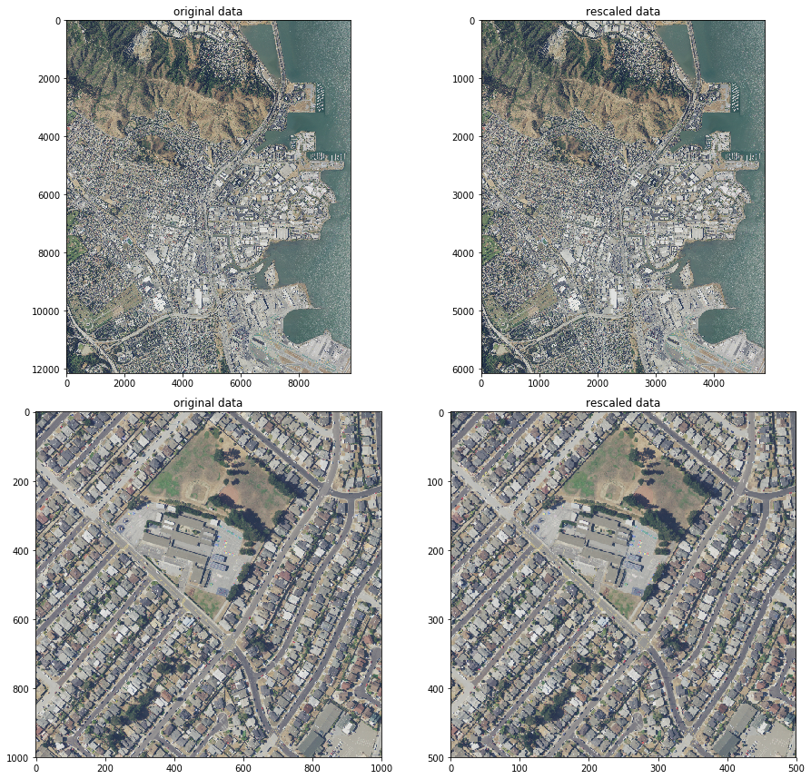

```python
in_arr = np.moveaxis(ds.ReadAsArray(), 0, -1)
out_arr = np.moveaxis(out_ds.ReadAsArray(), 0, -1)
fig, axs = plt.subplots(nrows=2, ncols=2, figsize=(15,15))
fig.subplots_adjust(hspace=0.1)
axs[0,0].imshow(in_arr[:,:,:3])
axs[0,0].set_title("original data")
axs[0,1].imshow(out_arr[:,:,:3])
axs[0,1].set_title("rescaled data")
axs[1,0].imshow(in_arr[4000:5000,0:1000,:3])
axs[1,0].set_title("original data")
axs[1,1].imshow(out_arr[2000:2500,0:500,:3])
axs[1,1].set_title("rescaled data")
plt.show()
```

## Part 3: Clipping rasters with polygons

GDAL Warp can also be used to clip rasters. The dataset used to define the extent of the clip can be any supported GDAL vector format such as a Shapefile, PostGIS record, GeoJSON, KML, etc. (even the dreaded Arc/Info E00 coverage if you so desire).

```python
in_shapefile = "D:/imagery/naip/ggez_shp/ggez.shp" #GG EZ BOIIIYSS!
ds = gdal.Open(image_filename)

"""
here are some arguments in gdal.Warp() that are related to clipping.

cutlineDSName --- cutline dataset name
cutlineLayer --- cutline layer name
cutlineWhere --- cutline WHERE clause
cutlineSQL --- cutline SQL statement
cutlineBlend --- cutline blend distance in pixels
cropToCutline --- whether to use cutline extent for output bounds
"""

warp_opts = gdal.WarpOptions(cutlineDSName=in_shapefile,
                             format="MEM",
                             cropToCutline=True)
out_ds = gdal.Warp(srcDSOrSrcDSTab=ds,
                   destNameOrDestDS="",
                   options=warp_opts)

orig_arr = np.moveaxis(ds.ReadAsArray(), 0, -1)[:,:,:3]
out_arr = np.moveaxis(out_ds.ReadAsArray(), 0, -1)[:,:,:3]
```

#### Some plots

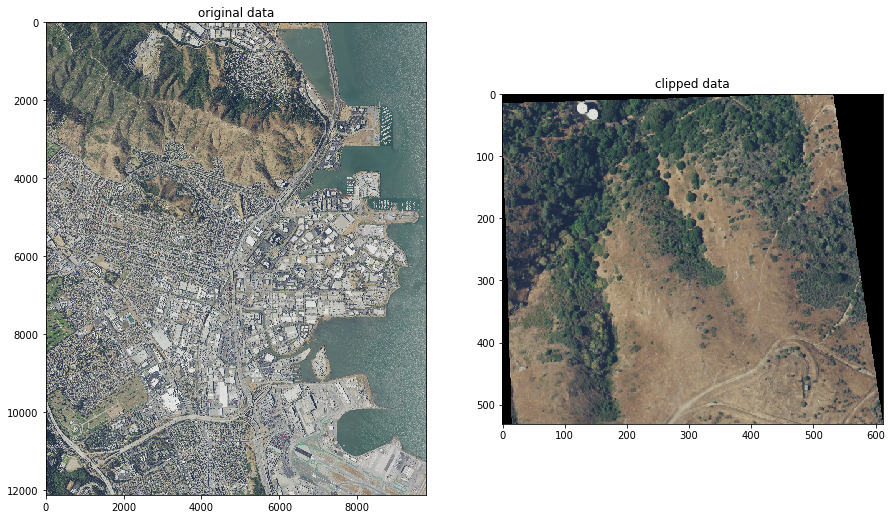

```python
fig, axs = plt.subplots(nrows=1, ncols=2, figsize=(15,15))
fig.subplots_adjust(hspace=0.1)
axs[0].imshow(orig_arr)
axs[0].set_title("original data")
axs[1].imshow(out_arr)
axs[1].set_title("clipped data")
plt.show()
```